# Une manière d’évaluer un modèle de prédiction

2024-12-15

#Nécessité d’évaluer les modèles de prédiction

Évaluer les performances d’un modèle de prédiction est primordial :

- Pour savoir si le modèle est globalement significatif. Mon modèle traduit-il vraiment une causalité ?
  - Pour se donner une idée des performances en déploiement. Quelle sera la fiabilité (les coûts associés) lorsque j’utiliserai mon modèle ?
  - Pour comparer plusieurs modèles candidats. Lequel parmi plusieurs modèles sera le plus performant compte tenu de mes objectifs ?

#Chargement des données

```r
suppressMessages(library(tidyverse))
suppressMessages(library(randomForest))
suppressMessages(library(plotROC))
suppressMessages(library(caret))


seed <- 754
set.seed(seed)
load(file='donnees/lesSurvivantsDuTitanic.apprentissage.model.RData')
varpredict <- names(echantillonApprentissage)[-1]
```

# 1 Random Forest

```r
# fit model
fit.randomForest <- randomForest(Survivant~., data=echantillonApprentissage, ntree=100)

# summarize the fit
print(fit.randomForest)
```

```
##
## Call:
##  randomForest(formula = Survivant ~ ., data = echantillonApprentissage,      ntree = 100)
##                Type of random forest: classification
##                      Number of trees: 100
## No. of variables tried at each split: 17
##
##         OOB estimate of  error rate: 18.63%
## Confusion matrix:
##     0   1 class.error
## 0 428  57   0.1175258
## 1  90 214   0.2960526
```

```r
# make predictions
predictions <- predict(fit.randomForest, echantillonValidation[,varpredict], type="class")
# summarize accuracy
confusionMatrix(predictions, echantillonValidation$Survivant)
```

```
## Confusion Matrix and Statistics
##
##           Reference
## Prediction  0  1
##          0 55 11
##          1  9 27
##
##                Accuracy : 0.8039
##                  95% CI : (0.7135, 0.8759)
##     No Information Rate : 0.6275
##     P-Value [Acc > NIR] : 9.127e-05
##
##                   Kappa : 0.5761
##
##  Mcnemar's Test P-Value : 0.8231
##
##             Sensitivity : 0.8594
##             Specificity : 0.7105
##          Pos Pred Value : 0.8333
##          Neg Pred Value : 0.7500
##              Prevalence : 0.6275
##          Detection Rate : 0.5392
##    Detection Prevalence : 0.6471
##       Balanced Accuracy : 0.7850
##
##        'Positive' Class : 0
##
```

```r
rfTestPred <- predict(fit.randomForest, echantillonValidation[,varpredict], type="prob")

jeuxTest <- data.frame(ModelProb = rfTestPred[,1])
jeuxTest$PredClass  <- predict(fit.randomForest, echantillonValidation[,varpredict], type="class")
jeuxTest$Class      <- echantillonValidation$Survivant
jeuxTest |> arrange(desc(ModelProb)) -> jeuxTest
```

# 2 Définitions

Le taux d’erreur semble être un indicateur synthétique pertinent, il indique (estime) la probabilité de mal classer un individu de la population.

##Le taux d’erreur : un indicateur trop réducteur

[figure not shown]

###Matrice de Confusion

```r
confusionMatrix(jeuxTest$PredClass,jeuxTest$Class)
```

```
## Confusion Matrix and Statistics
##
##           Reference
## Prediction  0  1
##          0 55 11
##          1  9 27
##
##                Accuracy : 0.8039
##                  95% CI : (0.7135, 0.8759)
##     No Information Rate : 0.6275
##     P-Value [Acc > NIR] : 9.127e-05
##
##                   Kappa : 0.5761
##
##  Mcnemar's Test P-Value : 0.8231
##
##             Sensitivity : 0.8594
##             Specificity : 0.7105
##          Pos Pred Value : 0.8333
##          Neg Pred Value : 0.7500
##              Prevalence : 0.6275
##          Detection Rate : 0.5392
##    Detection Prevalence : 0.6471
##       Balanced Accuracy : 0.7850
##
##        'Positive' Class : 0
##
```

[figure not shown]

Cette conclusion – basée sur l’échantillon test – suppose que la matrice de coût de mauvais classement est symétrique et unitaire.

Lorsque les classes sont très déséquilibrées, la matrice de confusion et surtout le taux d’erreur donnent souvent une fausse idée de la qualité de l’apprentissage. Cette anomalie est liée au fait que nous voulons absolument que le modèle réalise un affectation (positif ou négatif). Or dans de nombreux domaines, ce qui nous intéresse avant tout, c’est de mesurer la propension à être positif ou négatif !

##Les autres indicateurs

Les autres indicateurs sont très intéressants également (sensibilité/rappel, spécificité/précision) mais obligent à surveiller plusieurs valeurs simultanément.

[figure not shown]

Matrice Confusion

```r
probabilite <- jeuxTest$ModelProb
observations <- jeuxTest$Class
predictions  <- jeuxTest$PredClass
matriceConfusion <- table(predictions, observations)
vraisPositifs <- matriceConfusion[1,1]
fauxNegatifs  <- matriceConfusion[2,1]
fauxPositifs  <- matriceConfusion[1,2]
vraisNegatifs <- matriceConfusion[2,2]

sensibilite <- vraisPositifs / (vraisPositifs + fauxNegatifs)
specificite <- vraisNegatifs / (fauxPositifs  + vraisNegatifs)
prevalence  <- (vraisPositifs + fauxNegatifs) / (vraisPositifs + fauxPositifs + fauxNegatifs  + vraisNegatifs)

ValeurPreditePositive  <- sensibilite * prevalence / (sensibilite * prevalence + ((1 - specificite)*(1 - prevalence)))
ValeurPrediteNegative  <- specificite * (1 - prevalence) / ((prevalence * (1 - sensibilite)) + (specificite*(1 - prevalence)))
```

```r
print(paste('Sensibilité = ',sensitivity(predictions, observations)))
```

```
## [1] "Sensibilité =  0.859375"
```

```r
print(paste('Sensibilité = ',sensitivity(matriceConfusion)))
```

```
## [1] "Sensibilité =  0.859375"
```

```r
print(paste('Valeur prédite positive = ',posPredValue(predictions, observations)))
```

```
## [1] "Valeur prédite positive =  0.833333333333333"
```

```r
print(paste('Valeur prédite positive au seuil de prévalence 25% = ',posPredValue(predictions, observations, prevalence = 0.25)))
```

```
## [1] "Valeur prédite positive au seuil de prévalence 25% =  0.49738219895288"
```

```r
print(paste('Spécificité = ',specificity(predictions, observations)))
```

```
## [1] "Spécificité =  0.710526315789474"
```

```r
print(paste('Valeur prédite négative = ',negPredValue(predictions, observations)))
```

```
## [1] "Valeur prédite négative =  0.75"
```

```r
print(paste('Valeur prédite négative à partir de matrice de confusion = ',negPredValue(matriceConfusion)))
```

```
## [1] "Valeur prédite négative à partir de matrice de confusion =  0.75"
```

```r
print(paste('Valeur prédite négative au seuil de prévalence 25% = ',negPredValue(predictions, observations, prevalence = 0.25)))
```

```
## [1] "Valeur prédite négative au seuil de prévalence 25% =  0.938110749185668"
```

```r
tab.prevalence <- seq(0.001, .99, length = 20)
npvVals <- ppvVals <- tab.prevalence  * NA
for(i in seq(along = tab.prevalence)){
    ppvVals[i] <- posPredValue(predictions, observations, prevalence = tab.prevalence[i])
    npvVals[i] <- negPredValue(predictions, observations, prevalence = tab.prevalence[i])}
```

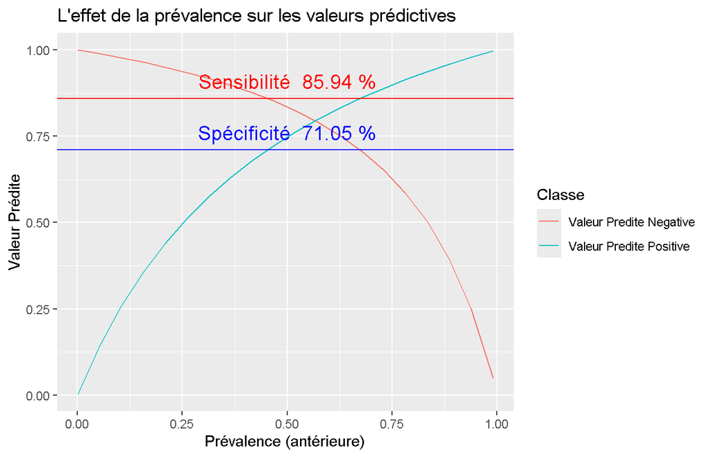

```r
distModel <-  rbind(data.frame(prevalence = tab.prevalence,
                        ValeurPredite = ppvVals,
                        Classe = rep('Valeur Predite Positive',length(tab.prevalence))),
                   data.frame(prevalence = tab.prevalence,
                        ValeurPredite = npvVals,
                        Classe = rep('Valeur Predite Negative',length(tab.prevalence))))

ggplot(distModel) +
geom_line(aes(x=prevalence, y=ValeurPredite, colour = Classe))+
geom_hline(yintercept = sensibilite,color="red")+
geom_hline(yintercept = specificite,color="blue")+
  annotate("text",x=0.5,y=sensibilite + 0.05,label=paste("Sensibilité ",round(sensibilite*100,2),"%"),color="red",size=5) +
  annotate("text",x=0.5,y=specificite + 0.05,label=paste("Spécificité ",round(specificite*100,2),"%"),color="blue",size=5) +
  xlab("Prévalence (antérieure)") +
  ylab("Valeur Prédite") +
  ggtitle("L'effet de la prévalence sur les valeurs prédictives")
```

[figure not shown]

```r
library(reshape2)
melted_cormat <- melt(round(cor(mtcars[, c(1,3,4,5,6,7)]),2))
ggplot(data = melted_cormat, aes(x=Var1, y=Var2, fill=value)) + geom_tile()
```

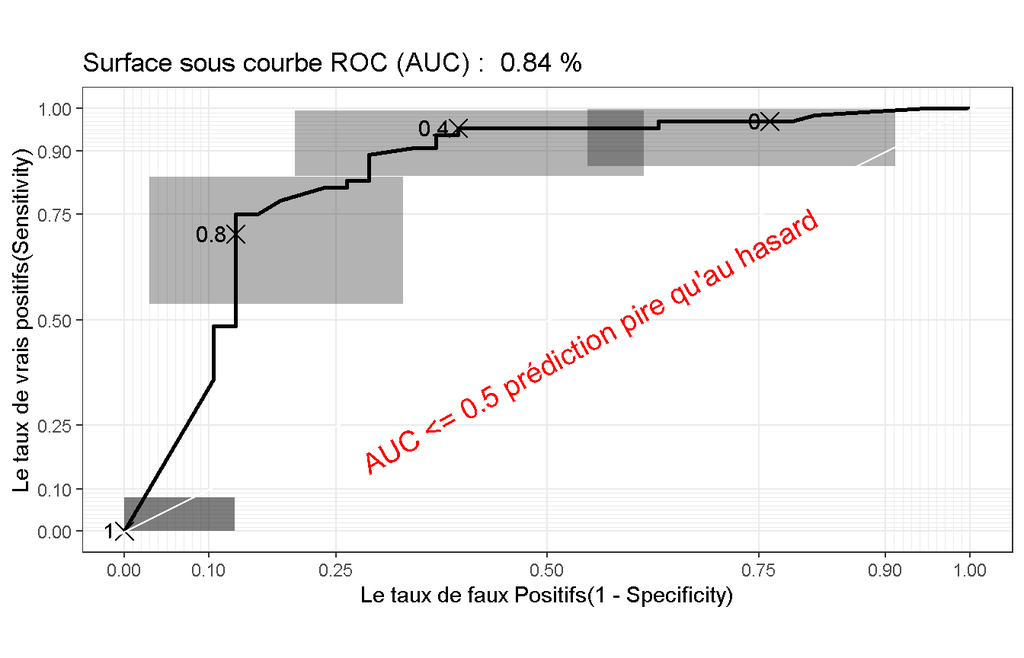

```r
donneesModel <- data.frame(Survivant = as.integer(jeuxTest$Class), Survivant.Nom = as.character(jeuxTest$Class),
                   ModelProb = jeuxTest$ModelProb)

basicplot <- ggplot(donneesModel, aes(d = 1 - Survivant, m = ModelProb))+ geom_roc(n.cuts = 0)

basicplot<- basicplot  +
  geom_rocci(ci.at = quantile(donneesModel$ModelProb, c(.1, .25, .5, .75, .9)),sig.level = .01) +
  style_roc(xlab='Le taux de faux Positifs(1 - Specificity)',ylab='Le taux de vrais positifs(Sensitivity)')+
  annotate("text",x=0.55,y=0.45,label="AUC <= 0.5 prédiction pire qu'au hasard",color="red",size=5, angle=29) +
  ggtitle(paste('Surface sous courbe ROC (AUC) : ',round(calc_auc(basicplot)$AUC,3),"%")) + coord_fixed(ratio = 1/2)

basicplot
```